# Study of Severe Weather Events and their impact on population health and economic consequences

Venkata Yerubandi

January 23, 2015

#### Synopsis

All weather events have health(injuries/fatalities) and economic consequences(property/crop damages) for counties.

This project involves exploring the U.S. National Oceanic and Atmospheric Administration’s (NOAA) storm database

[National Weather Service Storm Data Documentation](https://d396qusza40orc.cloudfront.net/repdata%2Fpeer2_doc%2Fpd01016005curr.pdf)

[National Climatic Data Center Storm Events FAQ](https://d396qusza40orc.cloudfront.net/repdata%2Fpeer2_doc%2FNCDC%20Storm%20Events-FAQ%20Page.pdf)

to address the following questions:

1. Across the United States, which types of events (as indicated in the EVTYPE variable) are most harmful with respect to population health?
2. Across the United States, which types of events have the greatest economic consequences?

#### Data Processing

```r
# unzip the data file
bunzip2("repdata-data-StormData.csv.bz2","repdata-data-StormData.csv",remove=FALSE,overwrite=TRUE)
stormdata<-read.csv("repdata-data-StormData.csv")

# look at the storm data topology
str(stormdata)
```

```
## 'data.frame':    902297 obs. of  37 variables:
##  $ STATE__   : num  1 1 1 1 1 1 1 1 1 1 ...
##  $ BGN_DATE  : Factor w/ 16335 levels "1/1/1966 0:00:00",..: 6523 6523 4242 11116 2224 2224 2260 383 3980 3980 ...
##  $ BGN_TIME  : Factor w/ 3608 levels "00:00:00 AM",..: 272 287 2705 1683 2584 3186 242 1683 3186 3186 ...
##  $ TIME_ZONE : Factor w/ 22 levels "ADT","AKS","AST",..: 7 7 7 7 7 7 7 7 7 7 ...
##  $ COUNTY    : num  97 3 57 89 43 77 9 123 125 57 ...
##  $ COUNTYNAME: Factor w/ 29601 levels "","5NM E OF MACKINAC BRIDGE TO PRESQUE ISLE LT MI",..: 13513 1873 4598 10592 4372 10094 1973 23873 24418 4598 ...
##  $ STATE     : Factor w/ 72 levels "AK","AL","AM",..: 2 2 2 2 2 2 2 2 2 2 ...
##  $ EVTYPE    : Factor w/ 985 levels "   HIGH SURF ADVISORY",..: 834 834 834 834 834 834 834 834 834 834 ...
##  $ BGN_RANGE : num  0 0 0 0 0 0 0 0 0 0 ...
##  $ BGN_AZI   : Factor w/ 35 levels "","  N"," NW",..: 1 1 1 1 1 1 1 1 1 1 ...
##  $ BGN_LOCATI: Factor w/ 54429 levels ""," Christiansburg",..: 1 1 1 1 1 1 1 1 1 1 ...
##  $ END_DATE  : Factor w/ 6663 levels "","1/1/1993 0:00:00",..: 1 1 1 1 1 1 1 1 1 1 ...
##  $ END_TIME  : Factor w/ 3647 levels ""," 0900CST",..: 1 1 1 1 1 1 1 1 1 1 ...
##  $ COUNTY_END: num  0 0 0 0 0 0 0 0 0 0 ...
```

[output cut: 23 more lines]

```r
# look at stormdata$PROPDMGEXP and stormdata$CROPDMGEXP
# expenditure is encoded as B for Billion etc
unique(stormdata$PROPDMGEXP)
```

```
##  [1] K M   B m + 0 5 6 ? 4 2 3 h 7 H - 1 8
## Levels:  - ? + 0 1 2 3 4 5 6 7 8 B h H K m M
```

```r
unique(stormdata$CROPDMGEXP)
```

```
## [1]   M K m B ? 0 k 2
## Levels:  ? 0 2 B k K m M
```

```r
# normalize expenditure indicators
# B is encoded as numeric billion etc
# assumption - a expenditore of a numeric 2 is encoded as 10^2
# +/- are assigned a 0
stormdata$PROPDMGEXP <- factor(tolower(stormdata$PROPDMGEXP))
stormdata$CROPDMGEXP <- factor(tolower(stormdata$CROPDMGEXP))
stormdata$PROPDMGEXP <- as.numeric(recode(as.character(stormdata$PROPDMGEXP),
                                          "'0'=1;'1'=10;'2'=10^2;'3'=10^3;'4'=10^4;'5'=10^5;'6'=10^6;'7'=10^7;'8'=10^8;'b'=10^9;'h'=10^2;'k'=10^3;'m'=10^6;'-'=0;'?'=0;'+'=0"))
stormdata$CROPDMGEXP <- as.numeric(recode(as.character(stormdata$CROPDMGEXP),
                                          "'0'=1;'1'=10;'2'=10^2;'3'=10^3;'4'=10^4;'5'=10^5;'6'=10^6;'7'=10^7;'8'=10^8;'b'=10^9;'h'=10^2;'k'=10^3;'m'=10^6;'-'=0;'?'=0;'+'=0"))
# calculate property and crop damage values in dollars
stormdata$PROPDMGDOLLAR <- stormdata$PROPDMG * stormdata$PROPDMGEXP
stormdata$CROPDMGDOLLAR <- stormdata$CROPDMG * stormdata$CROPDMGEXP
```

##### Creating Aggregations (Injuries/Fatalities by event types , Crop/Property damages by event types)

For computing all aggregations we performing the following sequence of steps

1. Aggregate the desired column across event type
2. Filter out the values which do not add value like rows with a zero value
3. Sort the result and pick top 10 items
4. Use the top 10 items in plots

Aggregrate injuries across event type

```r
# 1a. Aggregrate injuries across evttype
totalinjuriesbyevttype<-aggregate(stormdata$INJURIES, by=list(evtype=stormdata$EVTYPE), FUN=sum)
#rename columns
colnames(totalinjuriesbyevttype) <- c("evtype","injuries")
# remove all the rows with 0 values ( i.e no affect on population health )
nonzerototalinjuriesbyevttype<-totalinjuriesbyevttype[totalinjuriesbyevttype$injuries!=0,]
#head(nonzerototalinjuriesbyevttype)
# Since there are a lot of nonzero vectors , sort and plot the
# top 20
sortedtotalinjuriesbyevttype<-nonzerototalinjuriesbyevttype[order(-nonzerototalinjuriesbyevttype$injuries),]
top10sortedtotalinjuriesbyevttype<-sortedtotalinjuriesbyevttype[1:10,]
#head(top10sortedtotalinjuriesbyevttype)
```

Aggregrate fatalities across event type

```r
# 1b. Aggregrate fatalities across evttype
totalfatalitiesbyevttype<-aggregate(stormdata$FATALITIES, by=list(evtype=stormdata$EVTYPE), FUN=sum)
#rename columns
colnames(totalfatalitiesbyevttype) <- c("evtype","fatalities")
# remove all the rows with 0 values ( i.e no affect on population health )
nonzerototalfatalitiesbyevttype<-totalfatalitiesbyevttype[totalfatalitiesbyevttype$fatalities!=0,]
#head(nonzerototalfatalitiesbyevttype)
# Since there are a lot of nonzero vectors , sort and plot the
# top 20
sortedtotalfatalitiesbyevttype<-nonzerototalfatalitiesbyevttype[order(-nonzerototalfatalitiesbyevttype$fatalities),]
top10sortedtotalfatalitiesbyevttype<-sortedtotalfatalitiesbyevttype[1:10,]
#head(top10sortedtotalfatalitiesbyevttype)
```

Aggregrate PROPDMGEXP across event type

```r
# 2a. Aggregrate PROPDMGEXP across evttype
totalpropdmgbyevttype<-aggregate(stormdata$PROPDMGDOLLAR, by=list(evtype=stormdata$EVTYPE), FUN=sum)
#rename columns
colnames(totalpropdmgbyevttype) <- c("evtype","propdamage")
# remove all the rows with 0 values
nonzerototalpropdmgbyevttype<-totalpropdmgbyevttype[totalpropdmgbyevttype$propdamage!=0,]
#head(nonzerototalfatalitiesbyevttype)
# Since there are a lot of nonzero vectors , sort and plot the
# top 20
sortedtotalpropdmgbyevttype<-nonzerototalpropdmgbyevttype[order(-nonzerototalpropdmgbyevttype$propdamage),]
top10sortedtotalpropdmgbyevttype<-sortedtotalpropdmgbyevttype[1:10,]
```

Aggregrate CROPDMGEXP across event type

```r
# 2b. Aggregrate CROPDMGEXP across evttype
totalcropdmgbyevttype<-aggregate(stormdata$CROPDMGDOLLAR, by=list(evtype=stormdata$EVTYPE), FUN=sum)
#rename columns
colnames(totalcropdmgbyevttype) <- c("evtype","cropdamage")
# remove all the rows with 0 values
nonzerototalcropdmgbyevttype<-totalcropdmgbyevttype[totalcropdmgbyevttype$cropdamage!=0,]
#head(nonzerototalfatalitiesbyevttype)
# Since there are a lot of nonzero vectors , sort and plot the
# top 20
sortedtotalcropdmgbyevttype<-nonzerototalcropdmgbyevttype[order(-nonzerototalcropdmgbyevttype$cropdamage),]
top10sortedtotalcropdmgbyevttype<-sortedtotalcropdmgbyevttype[1:10,]
```

##### Across the United States, which types of events (as indicated in the EVTYPE variable) are most harmful with respect to population health?

To answer the above question , we use sorted injuries and fatalities calculated across evttype and plot them.

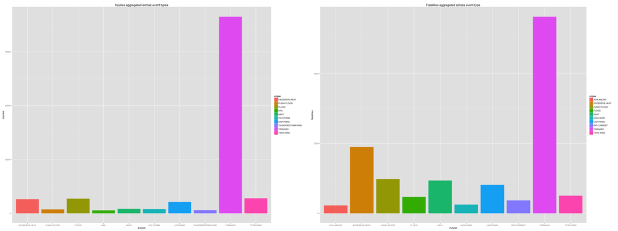

```r
ipbet<-ggplot(top10sortedtotalinjuriesbyevttype, aes(x=evtype,y=injuries)) + geom_bar(aes(fill=evtype), stat="identity")+ggtitle("Injuries aggregated across event types")

fpbet<-ggplot(top10sortedtotalfatalitiesbyevttype, aes(x=evtype,y=fatalities)) + geom_bar(aes(fill=evtype), stat="identity")+ggtitle("Fatalities aggregated across event type")

multiplot(ipbet , fpbet , cols=2)
```

###### Results

Events (as indicated in the EVTYPE variable) most harmful with respect to population health are

Top injuries by event type

```r
head(top10sortedtotalinjuriesbyevttype$evtype)
```

```
## [1] TORNADO        TSTM WIND      FLOOD          EXCESSIVE HEAT
## [5] LIGHTNING      HEAT
## 985 Levels:    HIGH SURF ADVISORY  COASTAL FLOOD ... WND
```

Top fatalities by event type

```r
head(top10sortedtotalfatalitiesbyevttype$evtype)
```

```
## [1] TORNADO        EXCESSIVE HEAT FLASH FLOOD    HEAT
## [5] LIGHTNING      TSTM WIND
## 985 Levels:    HIGH SURF ADVISORY  COASTAL FLOOD ... WND
```

##### Across the United States, which types of events have the greatest economic consequences?

To answer the above question , we use sorted crop damage and property damage expenditures calculated across evttype and plot them.

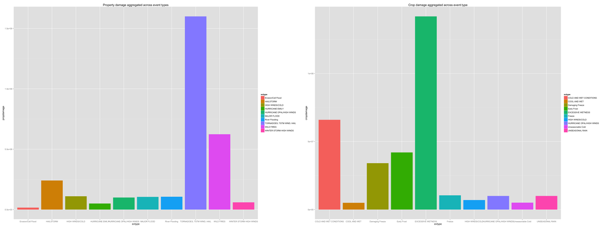

```r
library(ggplot2)
propdamagebet<-ggplot(top10sortedtotalpropdmgbyevttype, aes(x=evtype,y=propdamage)) + geom_bar(aes(fill=evtype), stat="identity")+ggtitle("Property damage aggregated across event types")

cropdamagebet<-ggplot(top10sortedtotalcropdmgbyevttype, aes(x=evtype,y=cropdamage)) + geom_bar(aes(fill=evtype), stat="identity")+ggtitle("Crop damage aggregated across event type")

multiplot(propdamagebet , cropdamagebet , cols=2)
```

###### Results

Events with greatest economic consequences

Top property damages by event type

```r
head(top10sortedtotalpropdmgbyevttype$evtype)
```

```
## [1] TORNADOES, TSTM WIND, HAIL WILD FIRES
## [3] HAILSTORM                  HIGH WINDS/COLD
## [5] River Flooding             MAJOR FLOOD
## 985 Levels:    HIGH SURF ADVISORY  COASTAL FLOOD ... WND
```

Top crop damages by event type

```r
head(top10sortedtotalcropdmgbyevttype$evtype)
```

```
## [1] EXCESSIVE WETNESS         COLD AND WET CONDITIONS
## [3] Early Frost               Damaging Freeze
## [5] Freeze                    HURRICANE OPAL/HIGH WINDS
## 985 Levels:    HIGH SURF ADVISORY  COASTAL FLOOD ... WND
```